# Section 12

Chris Carter

April 15, 2019

## Today

- Fixed effects
- Diff-in-diff
- RDD
- Optional: Review of MLE from problem set

Let’s say we are interested in understanding the effects of voting machines on spoiled ballots in different countries over time.

- What are our options?
- Panel data!

## Panel data

[output not shown]

Panel data (also known as longitudinal or time-series, cross-sectional data) is a data set in which the behavior of entities are observed across time. These entities could be states, companies, individuals, countries, etc.

```r
head(country_data)
```

```
##   country year            y        x1
## 1       A 1990  0.150179284 0.2779036
## 2       A 1991 -0.212460712 0.3206847
## 3       A 1992 -0.001256467 0.3634657
## 4       A 1993  0.295907244 0.2461440
## 5       A 1994  0.336456408 0.4246230
## 6       A 1995  0.361200123 0.4772141
```

For this exercise, we will focus on the heterogeneity across countries:

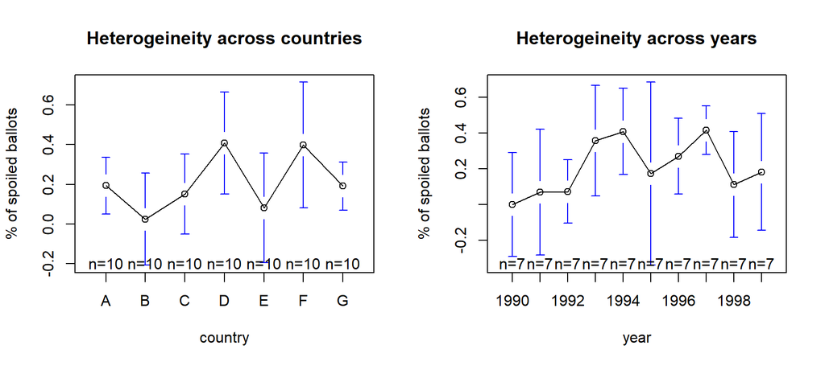

```r
par(mfrow=c(1,2))
plotmeans(y ~ country, main="Heterogeineity across countries", ylab = "% of spoiled ballots", data=country_data)
plotmeans(y ~ year, main="Heterogeineity across years", ylab = "% of spoiled ballots", data=country_data)
```

Regular OLS does not consider heterogeneity across groups or time…

```r
ols <-lm(y ~ x1, data=country_data)
summary(ols)
```

```
##
## Call:
## lm(formula = y ~ x1, data = country_data)
##
## Residuals:
##      Min       1Q   Median       3Q      Max
## -1.06764 -0.17643  0.01738  0.15905  0.80334
##
## Coefficients:
##             Estimate Std. Error t value Pr(>|t|)
## (Intercept)  0.17048    0.06946   2.454   0.0167 *
## x1           0.05536    0.08711   0.636   0.5272
## ---
## Signif. codes:  0 '***' 0.001 '**' 0.01 '*' 0.05 '.' 0.1 ' ' 1
##
## Residual standard error: 0.3387 on 68 degrees of freedom
## Multiple R-squared:  0.005905,   Adjusted R-squared:  -0.008714
## F-statistic: 0.4039 on 1 and 68 DF,  p-value: 0.5272
```

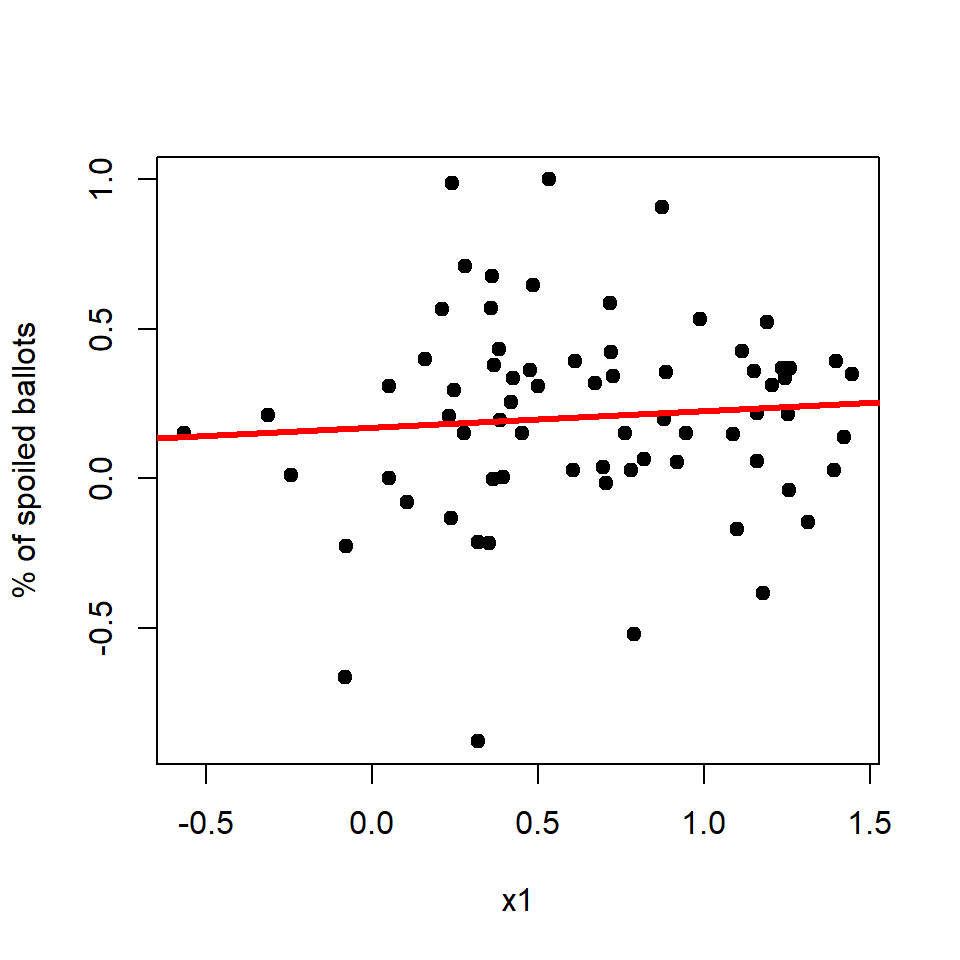

```r
par(mfrow=c(1,1))
plot(country_data$x1, country_data$y, pch=19, xlab="x1", ylab = "% of spoiled ballots")
abline(lm(country_data$y~country_data$x1),lwd=3, col="red")
```

## Fixed effects

Fixed-effects models help to isolate the effects of within-unit variation—though coefficients are pooled across units.

$$spoiled_{it}= \alpha_i + \beta D_{it} + \epsilon_{it}$$
where there is one dummy variable (“fixed effect”) $\alpha_i$ for each unit $i$ (here unit=country). This fixed-effect is a unit-specific intercept.

How will the design matrix look here?

What does problems of a normal regression might be solved in this fixed effects design?

```r
fixed.dum <-lm(y ~ x1 + factor(country) - 1, data=country_data)
summary(fixed.dum)
```

```
##
## Call:
## lm(formula = y ~ x1 + factor(country) - 1, data = country_data)
##
## Residuals:
##      Min       1Q   Median       3Q      Max
## -0.96564 -0.10845  0.06045  0.15506  0.62770
##
## Coefficients:
##                  Estimate Std. Error t value Pr(>|t|)
## x1                0.27688    0.12377   2.237  0.02889 *
## factor(country)A  0.09848    0.10757   0.916  0.36347
## factor(country)B -0.11831    0.11755  -1.006  0.31811
## factor(country)C -0.19268    0.18247  -1.056  0.29508
## factor(country)D  0.35374    0.10172   3.478  0.00093 ***
## factor(country)E -0.06740    0.11903  -0.566  0.57329
## factor(country)F  0.22488    0.12558   1.791  0.07821 .
## factor(country)G -0.11013    0.16695  -0.660  0.51190
## ---
## Signif. codes:  0 '***' 0.001 '**' 0.01 '*' 0.05 '.' 0.1 ' ' 1
##
## Residual standard error: 0.3127 on 62 degrees of freedom
## Multiple R-squared:  0.4402, Adjusted R-squared:  0.368
## F-statistic: 6.095 on 8 and 62 DF,  p-value: 8.892e-06
```

Each component of the factor variable (country) is absorbing the variation particular to each country.

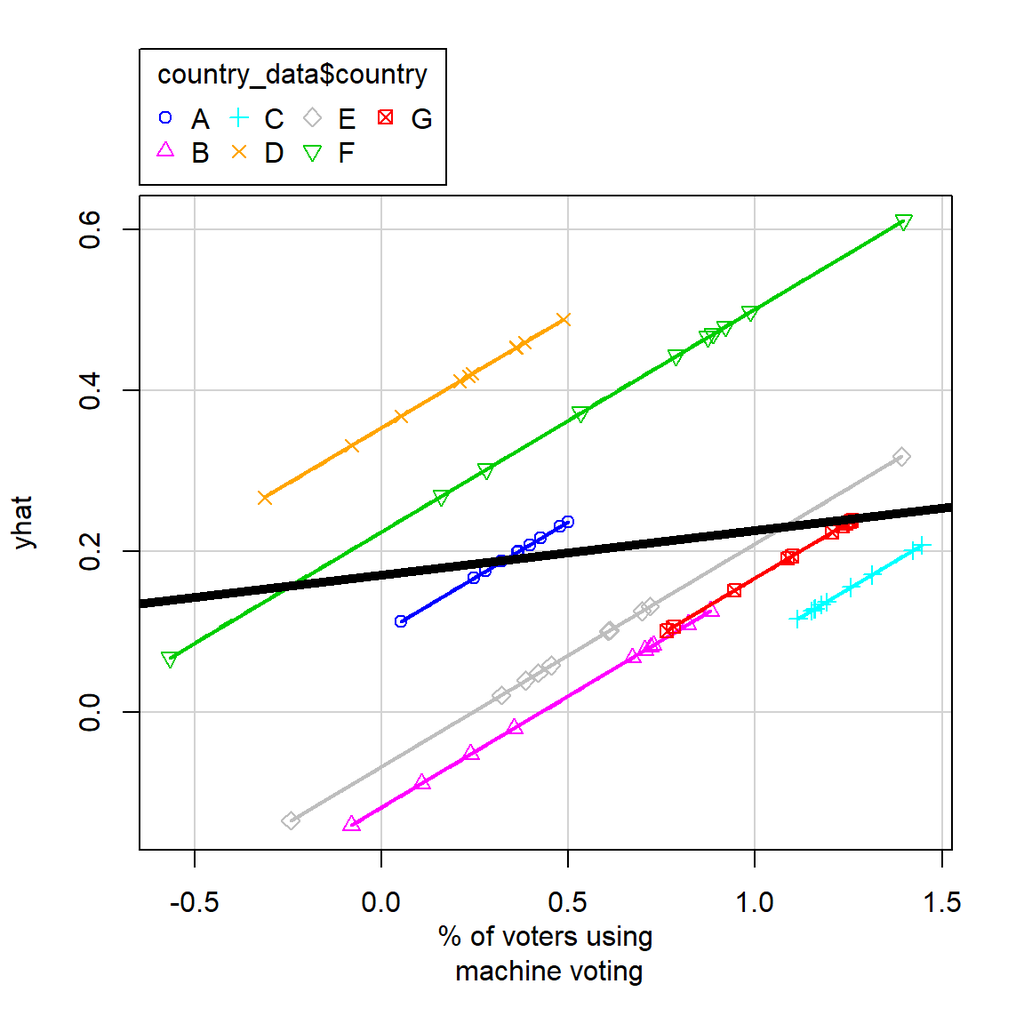

```r
yhat <- fixed.dum$fitted
scatterplot(yhat~country_data$x1|country_data$country,
            xlab="% of voters using\n machine voting", ylab="yhat")
abline(lm(country_data$y~country_data$x1), lwd=5, col="black")
```

Let’s say we are interested in understanding the effects of voting machines on spoiled ballots in Elbonia. We find half the states implemented the electronic voting in 1998 and half did not. He has data from the 1996 and 1998 presidential elections.

- He runs the following regression with precincts, $i$:
  $$\%\_spoiled_{i} = \beta_{0} + \beta_{1}electronic_{i} + \beta_{2}1998_{i} + \beta_{3}electronic_{i} \times 1998_{i} + \epsilon_{i}$$
- What is this design?
- What coefficient do we want to interpret?
- What might be a problem here with the estimate and its (estimated) variance?

## Regression Discontinuity Design

- Lots of desirable properties.
- But some challenges…
- Estimand: Local linear vs. local randomization
- Also: Bandwidth choice, polynomial order, kernel weight
- Interpretation: What effect are we identifying?

## Regression Discontinuity Design

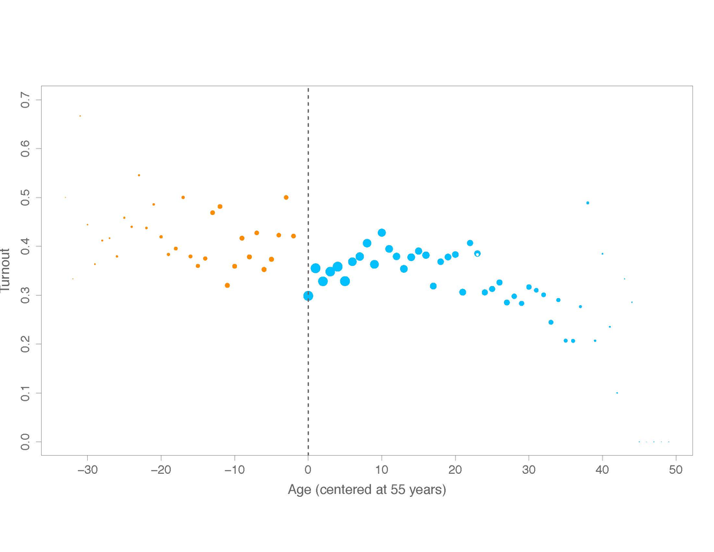

## Regression Discontinuity Design

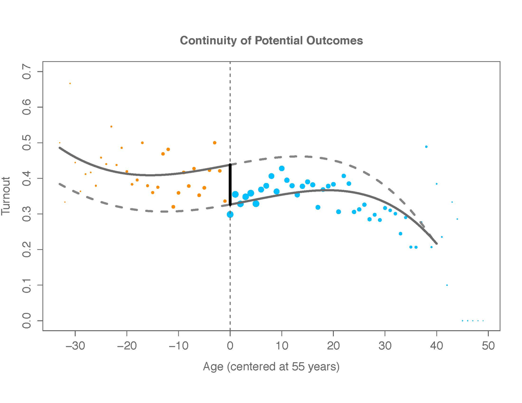

Back to the example of voting machines…

Hidalgo - Electronic Voting

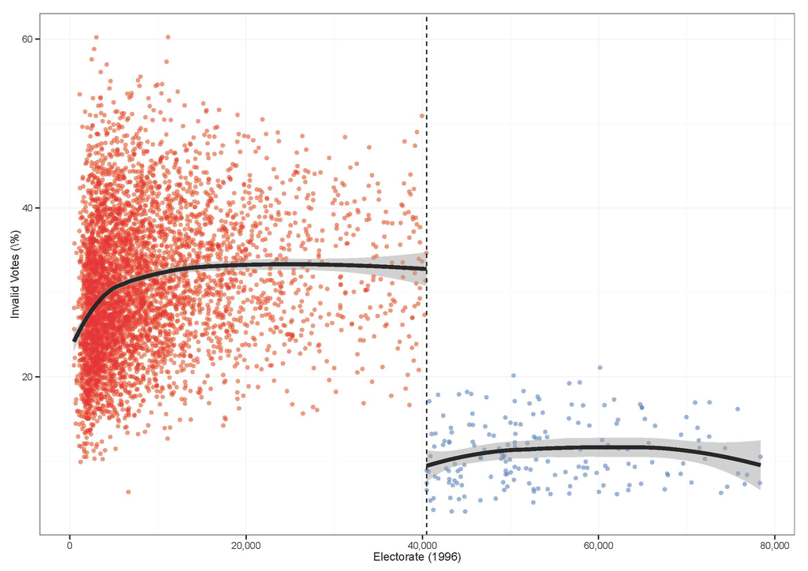

## Exercise

[figure not shown]

We will use `rddata.Rda` to estimate the effect of having a left-wing party in office on social spending

```r
load("rddata.Rda")
head(data)
```

```
##   municipality  party  vs_2000  vs_2004 soc_spend
## 1            1 center 41.72421 36.56648  40.67018
## 2            1   left 43.23756 46.25497  48.98232
## 3            1  right 15.03822 17.17855  10.34750
## 4            2   left 33.82809 37.67917  37.96897
## 5            2  right 35.08161 37.52963  35.12098
## 6            2 center 31.09030 24.79119  26.91006
```

```r
# How many municipalities?
length(unique(data$municipality))
```

```
## [1] 6000
```

```r
# How many candidates per municipality?
nr_cand <- NA
for (i in 1:6000){ nr_cand[i] <- nrow(data[data$municipality==i,]) }
mean(nr_cand)
```

```
## [1] 3
```

```r
sd(nr_cand)
```

```
## [1] 0
```

```r
# NA observations for running variable?
sum(is.na(data$vs_2000))
```

```
## [1] 0
```

What type of dataset do we need for the RD analysis? How can we build it?

```r
# Building RD dataset
rd_data <- NA

for (i in 1:6000){

    # get mini muni data
    temp <- data[data$municipality==i, ]
    # 1. keep winner and loser
    temp$order <- order(temp$vs_2000, decreasing = TRUE)
    temp <- temp[temp$order!=3, ]

    # 2. drop if no left
    temp$left <- ifelse(temp$party=="left", 1, 0)
    if (sum(temp$left)==0) {temp$margin <- NA}

    # 3. left margin
    if (sum(temp$left)==1){
        temp$margin <- temp$vs_2000[temp$left==1] -
            temp$vs_2000[temp$left==0]}

    # put together in final dataset
    rd_data <- rbind(rd_data, temp)

    if (i/1000==round(i/1000)) print(i)

}
```

```
## [1] 1000
## [1] 2000
## [1] 3000
## [1] 4000
## [1] 5000
## [1] 6000
```

```r
head(rd_data)
```

```
##   municipality  party  vs_2000  vs_2004 soc_spend order left    margin
## 1           NA   <NA>       NA       NA        NA    NA   NA        NA
## 2            1 center 41.72421 36.56648  40.67018     2    0  1.513347
## 3            1   left 43.23756 46.25497  48.98232     1    1  1.513347
## 4            2   left 33.82809 37.67917  37.96897     2    1 -1.253524
## 5            2  right 35.08161 37.52963  35.12098     1    0 -1.253524
## 7            3 center 34.91674 33.81395  37.22732     2    0  3.415483
```

```r
# dropping cases with no left wing party winner or runner up
rd_data <- rd_data[is.na(rd_data$margin)==F, ]
head(rd_data)
```

```
##   municipality  party  vs_2000  vs_2004 soc_spend order left    margin
## 2            1 center 41.72421 36.56648  40.67018     2    0  1.513347
## 3            1   left 43.23756 46.25497  48.98232     1    1  1.513347
## 4            2   left 33.82809 37.67917  37.96897     2    1 -1.253524
## 5            2  right 35.08161 37.52963  35.12098     1    0 -1.253524
## 7            3 center 34.91674 33.81395  37.22732     2    0  3.415483
## 8            3   left 38.33222 48.28878  47.91241     1    1  3.415483
```

```r
dim(rd_data)
```

```
## [1] 8100    8
```

```r
length(unique(rd_data$municipality))
```

```
## [1] 4050
```

```r
# creating the treatment variable
rd_data$treat <- ifelse(rd_data$left==1 & rd_data$margin>=0, 1, 0)
table(rd_data$treat)
```

```
##
##    0    1
## 6042 2058
```

```r
# keeping only the winner
rd_data <- rd_data[rd_data$order==1, ]
table(rd_data$treat)
```

```
##
##    0    1
## 2064 1986
```

```r
# t-test in 5% margin
with(rd_data[abs(rd_data$margin)<=5, ],
     t.test(soc_spend ~ treat))
```

```
##
##  Welch Two Sample t-test
##
## data:  soc_spend by treat
## t = -28.315, df = 1611.6, p-value < 2.2e-16
## alternative hypothesis: true difference in means is not equal to 0
## 95 percent confidence interval:
##  -8.875902 -7.725876
## sample estimates:
## mean in group 0 mean in group 1
##        36.22034        44.52122
```

## Hidalgo - Electronic Voting

[figure not shown]

## Robustness tests

- Varying cutpoint
- Test for discontinuities in covariates at cutpoint (which?)
- In fuzzy design, test significance of ``first stage’’ discontinuity at cutpoint (next week)